# CANCER PREVENTION: HPV VACCINATION SCHEDULES

HPV Vaccine Quarto Report - 2025

Author

Léna Carreras

Published

April 27, 2025

### At a global scale, the HPV (Human papillomavirus) is causing cancers responsible for **350 000 deaths** in 2022.

However, the introduction of the **HPV vaccine** in 2006 allowed to fight this epidemic, through different prevention plans organized by **the WHO and the United Nations.** The goal nowadays is to vaccine **every girl under 15 years old** to prevent the apparition and transmission of the HPV, and a global detection campaign for every woman.

In 2023, **132 countries** have introduced a national vaccination schedule against HPV.

We chose **green** to illustrate this report because it is the color of the fight against the cervix cancer, the most common cancer caused by HPV.🎗

[Click here to donate and support research!](https://don.unicef.fr/don-ponctuel/~mon-don?_gl=1%2A1hidg1f%2A_gcl_au%2AMTUzNzcyMjY2LjE3NDU3NDU3MTc.%2AFPAU%2AMTUzNzcyMjY2LjE3NDU3NDU3MTc.&_ga=2.25616507.75440752.1745745718-441523937.1745745717)

# How the implementation of the vaccine evolved:

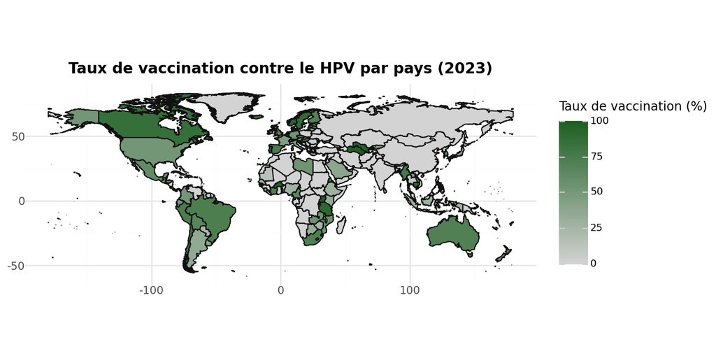

The map shows the vaccination rate globally in 2023. We can observe that some regions are darker, showing their intensive vaccination schedules to promote the protection against the different cancers cause by the HPV.

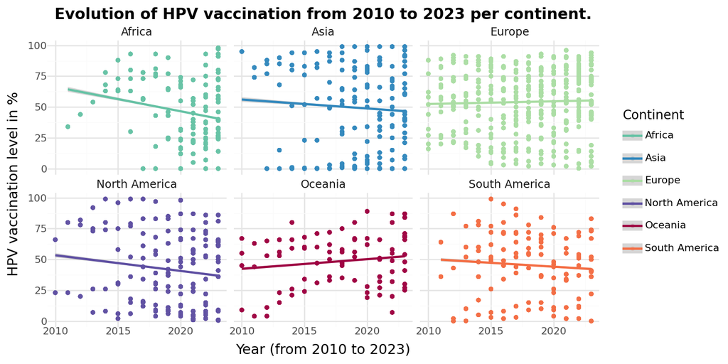

When seen more precisely on this graph, trends are diverse per region, but we can definitely see a bigger **density in Europe than in Africa** at the beginning of the vaccination implementation.

It demonstrates that vaccination rates are impacted by **external stimuli, like economic, social or political crisis**.

See underneath the global evolution of the vaccination schedule: this one proves that **Covid-19 had a very important impact** on the vaccination schedules, reducing the level by 10% in a year. This confirms the **external influence** that can exists on vaccination, especially against HPV.

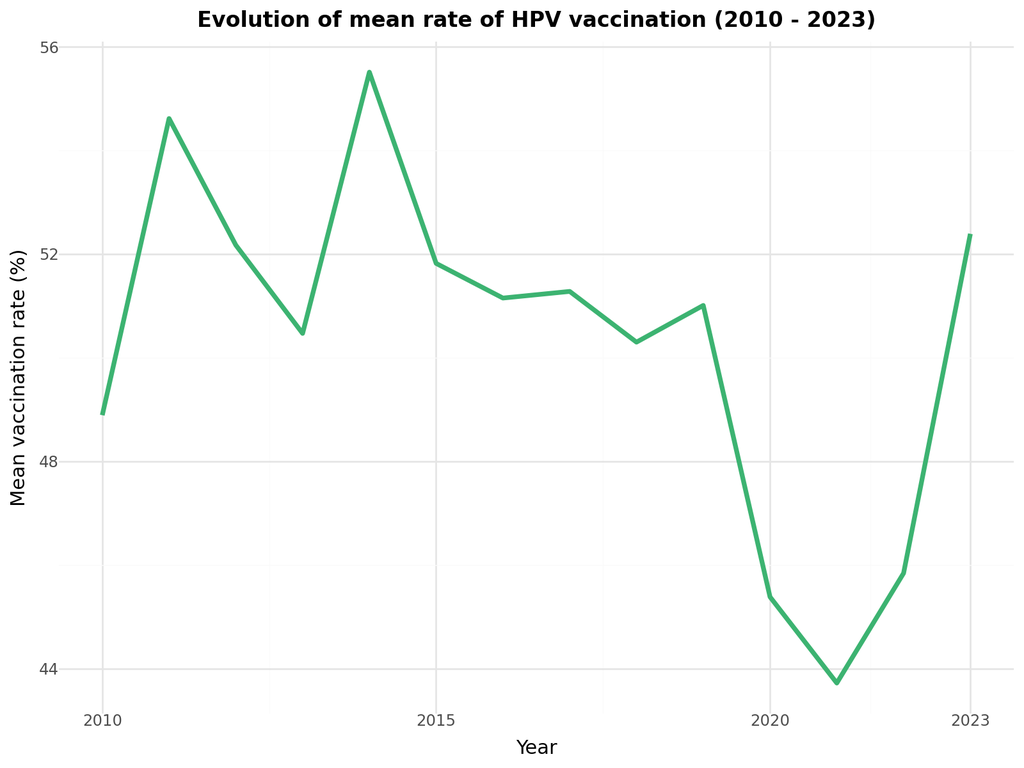

# Where can we find the most encouraging vaccination rates:

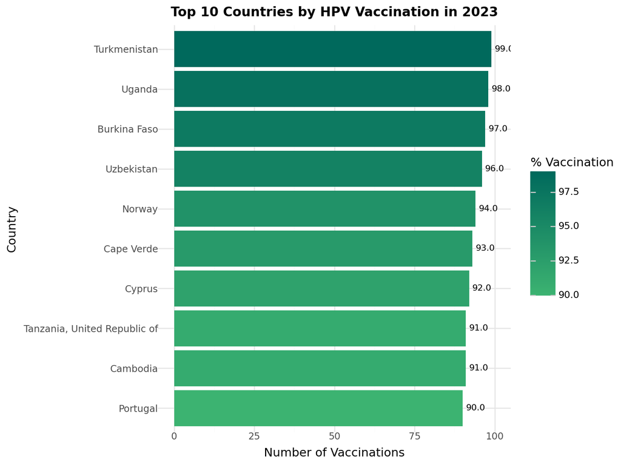

Analyzing a **top 10** shows that the vaccination rates can be exceptional. For example, **in Turkmenistan, in 2023, more than 90% of the 15-year-old girls** received the last dose of the HPV vaccine, protecting them from this type of cancer. Other examples like Portugal or Cape Verde are proving that a **massive prevention** is possible in every country.

|  | 0 | 1 | 2 | 3 | 4 | 5 | 6 | 7 | 8 | 9 | 10 | 11 | 12 | 13 | 14 |
| --- | --- | --- | --- | --- | --- | --- | --- | --- | --- | --- | --- | --- | --- | --- | --- |
| 0 | Cambodia | Eritrea | Swaziland | Kiribati | Libyan Arab Jamahiriya | Togo | Kyrgyzstan | Vanuatu | Sierra Leone | Saudi Arabia | Nigeria | Bangladesh | Montenegro | Romania | Bosnia and Herzegovina |
| 1 | 91.0 | 78.0 | 59.0 | 54.0 | 54.0 | 46.0 | 46.0 | 41.0 | 39.0 | 39.0 | 27.0 | 21.0 | 19.0 | 6.0 | 5.0 |

Each year, new countries are organizing HPV vaccination schedules. In 2023, **15 new countries** started vaccinating their population against HPV, with brilliant executions like Cambodia, which campaign reached **91% of the 15-year-old girls in one year**.

# Why some countries have yet to adopt the vaccine:

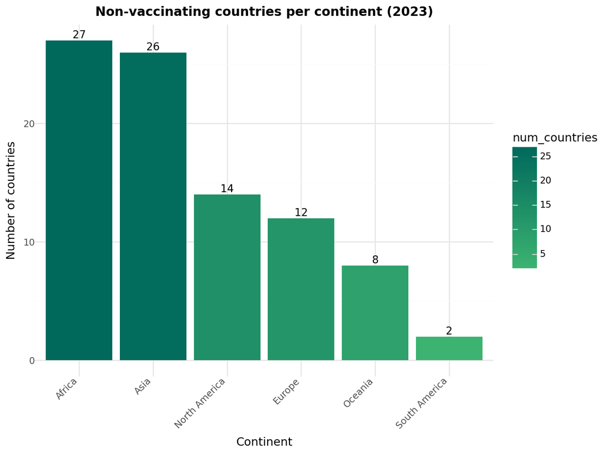

Even if vaccination is proven to be effective in **reducing the infection by the HPV virus**, some countries still haven’t implemented it.

- 👪 **Sexuality-related concerns**
- ⚖ **Gender inequalities**
- 🛐 **Upbringing and moral values**
- 🪳 **External influences**
- 💉**Vaccine-related concerns…**

The **5 themes** listed above are the most common reasons to refuse to vaccine teenage girls against this sexually-transmitted virus. Most of the non-vaccinating countries (displayed in grey on the map above) have strong moral and religious values that create limitations in HPV vaccination.

On the graph, a total of **89 countries** still haven’t adopted the vaccination, but through education and promotion, more population could be reached.

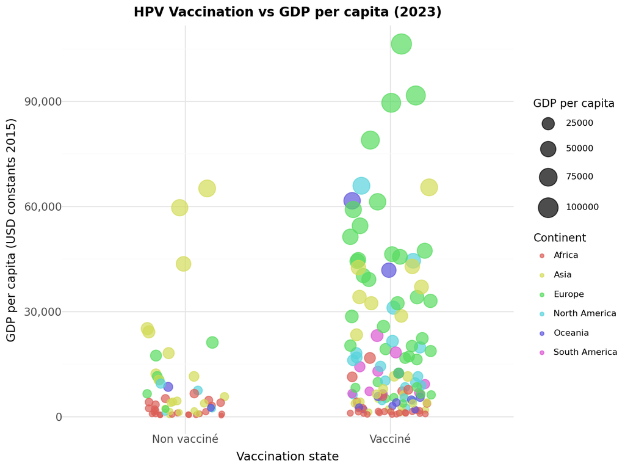

Through, some low-GDP countries are vaccinating too, proving that a **worldwide HPV vaccination is possible.**

## **HPV vaccination is more than a medical procedure, it is a powerful tool for prevention that can save lives. Together, let’s continue to promote access and awareness for a future free of preventable cancers.**

Source: UNICEF